# GENERI MUSICALI: RICONOSCIMENTO DEI GENERI TRAMITE IL DEEP LEARNING

Matteo Baldanza, Filippo Masi, Alessandro Zanotta

23/2/2022

Carichiamo le library necessarie per l’intero lavoro.

```r
library(tidymodels)
library(keras)
library(tensorflow)
library(tuneR)
library(seewave)
library(soundgen)
library(tictoc)
library(caret)
library(tfruns)
```

# PARTE 1

## Rete Neurale Convoluzionale

Per prima cosa si importano le immagini che sono in formato PNG. Il dataset contiene 1000 immagini di spettogrammi riferiti a 10 generi musicali differenti. Dopo aver fatto il download abbiamo creato tre sottoinsiemi: 700 immagini per il training set, 200 immagini per il validation set e 100 immagini per il test set. Si sono applicate trasformazioni in modo tale avere delle immagini in formato RGB (quindi di profondità del colore 3) e dimensioni 288x432 pixel.

```r
# Librerie -----------------------------
# Richiamo Directory Train e Validation --------------------------------------

feature_extrac = read.csv2("C:/Users/matte/Desktop/feature_extrac.csv")
feature_extrac$genre=as.factor(feature_extrac$genre)

original_dataset_dir = "C:/Users/matte/Desktop/genre_music/genre_music"

whole_data_dir = "C:/Users/matte/Desktop/genre_music/genre_music"

train_dir = file.path(whole_data_dir, "Train_genre")

validation_dir <- file.path(whole_data_dir, "Validation_genre")

test_dir <- file.path(whole_data_dir, "Test_genre")

train_datagen = image_data_generator(rescale = 1/255)
validation_datagen = image_data_generator(rescale = 1/255)
test_datagen = image_data_generator(rescale = 1/255)
```

```r
train_generator = flow_images_from_directory(
  train_dir,
  train_datagen,
  target_size = c(288, 432),
  batch_size = 20,
  class_mode = "categorical"
)
```

```r
validation_generator = flow_images_from_directory(
  validation_dir,
  validation_datagen,
  target_size = c(288, 432),
  batch_size = 20,
  class_mode = "categorical"
)
```

```r
test_generator = flow_images_from_directory(
  test_dir,
  test_datagen,
  target_size = c(288, 432),
  class_mode = "categorical",
  shuffle = F #non mischia le immagini-->Per confusion matric
)
```

Si è in seguito proceduto a partire dalla generazione di una rete semplice non troppo profonda, andando poi ad aggiungere layers e neuroni per migliorare l’adattamento dell’algoritmo ai dati di training e monitorando l’accuracy sul validation. La rete finale scelta è quella qui proposta. Il file creato in questione è caratterizzato da questi flags, parametri delle rete, che sono salvati esternamente perchè verranno modificati nella fase di tuning.

Dopo quest’analisi sulla profondità e struttura della rete si è giunti al risultato che la struttura della rete che meglio si è adattata ai dati, pur mantenendo una buona generalizzazione, è composta da tre strati convoluzionali ognuno seguito da altrattenti strati di pooling, legati tutti dalla funzione di attivazione relu. In seguito uno strato flatten che anticipava gli ultimi due strati feed forward.

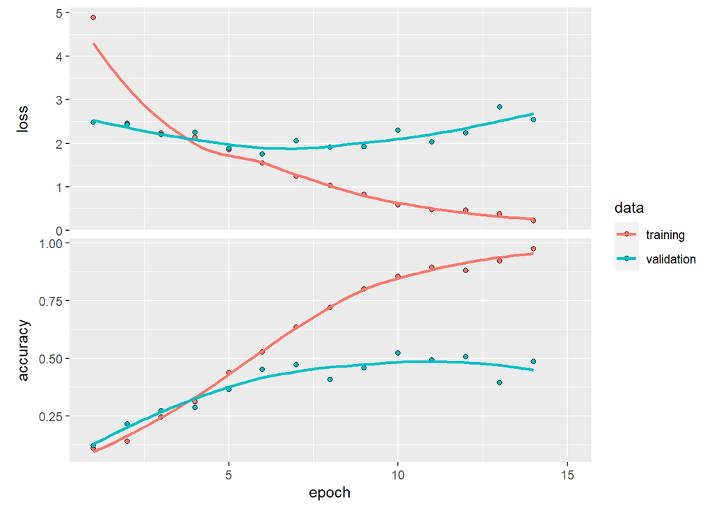

```r
# Tuning CNN ------------------------------------------

FLAGS <- flags(
  flag_numeric('dropout1', 0.2),
  flag_integer('neurons_conv_1', 64),
  flag_integer('neurons_conv_2', 128),
  flag_integer('neurons_conv_3', 256),
  flag_integer('kernel_size_1_x', 5),
  flag_integer('kernel_size_1_y', 5),
  flag_integer('kernel_size_2_x', 4),
  flag_integer('kernel_size_2_y', 4),
  flag_integer('kernel_size_3_x', 4),
  flag_integer('kernel_size_3_y', 4),
  flag_integer('neurons_dense1',258),
  flag_numeric('l2', 0.0001),
  flag_numeric('lr', 0.001)
)

build_model <- function(){
  model <- keras_model_sequential()
  model %>%
    layer_conv_2d(filters = FLAGS$neurons_conv_1,
                  kernel_size = c(FLAGS$kernel_size_1_x,FLAGS$kernel_size_1_y),
                  activation = "relu",input_shape = c(288,432,3),padding = "valid")%>%
    layer_max_pooling_2d(c(2,2),padding = "same")%>%
    layer_conv_2d(filters = FLAGS$neurons_conv_2,
                  kernel_size = c(FLAGS$kernel_size_2_x,FLAGS$kernel_size_2_y),
                  activation = "relu",padding = "valid")%>%
    layer_max_pooling_2d(c(2,2),padding = "same")%>%
    layer_conv_2d(filters = FLAGS$neurons_conv_3,
                  kernel_size = c(FLAGS$kernel_size_3_x,FLAGS$kernel_size_3_y),
                  activation = "relu")%>%
    layer_max_pooling_2d(c(2,2))%>%
    layer_flatten()%>%
    layer_dropout(FLAGS$dropout1) %>%
    layer_dense(units = FLAGS$neurons_dense1,
                activation = 'relu',kernel_regularizer = regularizer_l2(l = FLAGS$l2)) %>%
    layer_dense(units = 10,activation = "softmax")

  model %>% compile(
    loss = "categorical_crossentropy",
    optimizer = optimizer_adam(learning_rate = FLAGS$lr),
    metrics = "accuracy")
  model
}
model = build_model()

epochs <- 15 #giusto per mostrare come procede

early_stop = callback_early_stopping(
  monitor='val_loss', min_delta=0, patience=8, mode='auto')

# Fit the model and store training stats
history <- model %>% fit(
  train_generator,
  epochs = epochs,
  validation_data = validation_generator,
  batch_size=7,
  steps_per_epoch = 17,
  validation_steps=7,
  callbacks = early_stop
)

plot(history)
```

Il risultato della rete provata è il seguente:

```r
score <- model %>% evaluate(
  test_generator)
```

```r
cat('Test loss:', score[1], '\n')
```

```
Test loss: 3.496568
```

```r
cat('Test accuracy:', score[2], '\n')
```

```
Test accuracy: 0.44
```

La confusion matrix finale è:

```r
prev=model %>%
  predict(test_generator)%>%
  k_argmax()

prev=as.factor(as.numeric(prev)+1);levels(prev)=levels(feature_extrac$genre)

y=as.factor(test_generator$labels+1);levels(y)=levels(feature_extrac$genre)
confusionMatrix(prev,y)
```

```
Confusion Matrix and Statistics

           Reference
Prediction  blues classical country disco hiphop jazz metal pop reggae rock
  blues         3         1       3     0      1    4     0   0      2    4
  classical     1         7       0     0      0    0     0   0      0    0
  country       2         1       2     1      2    1     0   0      2    0
  disco         0         0       3     3      1    1     0   0      0    1
  hiphop        0         0       0     1      4    0     0   1      4    0
  jazz          0         0       0     0      0    4     0   0      1    0
  metal         0         0       1     0      0    0     7   0      0    1
  pop           0         0       0     0      1    0     0   9      0    0
  reggae        0         0       0     1      0    0     0   0      1    0
  rock          4         1       1     4      1    0     3   0      0    4

Overall Statistics

               Accuracy : 0.44
                 95% CI : (0.3408, 0.5428)
    No Information Rate : 0.1
    P-Value [Acc > NIR] : < 2.2e-16

                  Kappa : 0.3778

 Mcnemar's Test P-Value : NA

Statistics by Class:

                     Class: blues Class: classical Class: country Class: disco
Sensitivity                0.3000           0.7000         0.2000       0.3000
Specificity                0.8333           0.9889         0.9000       0.9333
Pos Pred Value             0.1667           0.8750         0.1818       0.3333
Neg Pred Value             0.9146           0.9674         0.9101       0.9231
Prevalence                 0.1000           0.1000         0.1000       0.1000
Detection Rate             0.0300           0.0700         0.0200       0.0300
Detection Prevalence       0.1800           0.0800         0.1100       0.0900
Balanced Accuracy          0.5667           0.8444         0.5500       0.6167
                     Class: hiphop Class: jazz Class: metal Class: pop
Sensitivity                 0.4000      0.4000       0.7000     0.9000
Specificity                 0.9333      0.9889       0.9778     0.9889
Pos Pred Value              0.4000      0.8000       0.7778     0.9000
Neg Pred Value              0.9333      0.9368       0.9670     0.9889
Prevalence                  0.1000      0.1000       0.1000     0.1000
Detection Rate              0.0400      0.0400       0.0700     0.0900
Detection Prevalence        0.1000      0.0500       0.0900     0.1000
Balanced Accuracy           0.6667      0.6944       0.8389     0.9444
                     Class: reggae Class: rock
Sensitivity                 0.1000      0.4000
Specificity                 0.9889      0.8444
Pos Pred Value              0.5000      0.2222
Neg Pred Value              0.9082      0.9268
Prevalence                  0.1000      0.1000
Detection Rate              0.0100      0.0400
Detection Prevalence        0.0200      0.1800
Balanced Accuracy           0.5444      0.6222
```

## Parte di Tuning

In questa parte di codice R si propone il tuning effettuato sulla rete neurale Cnn. Sono stati scelti a priori dei valori di iperparametri sulla base di prove effetuate in precedenza per evitare di appesantire il calcolo computazionale senza esser certi di un possibile miglioramente. Il comando tuining_run prende come input il codice R preparato in precedenza e lo esegue per ogni combinazione di parametri. Ad ogni esecuzione vengono salvati i risultati della rete e alla fine viene restituita la migliore. Si precisa che il codice in questione ha tempi di esecuzione particolarmente alti, una singola rete neurale convoluzionale impiega circa 30/40 minuti per performare (per come l’abbiamo ottimizzata/ideata noi). Questo per dire che se si provano circa 100 combinazioni il tempo di calcolo sulle macchine a nostra disposizione è di circa 3 giorni. Si prosegue quindi mostrando quanto utilizzato senza andare a rieseguirlo.

E’ stato necessario inserire dei parametri che evitassero il fenomeno di overfitting della rete perchè infatti senza di essi l’accuracy del training risultava prossima a $1$ ma molto distante dal risultato nel validation dove non superava lo $0.4$, testimoniando quindi un’ottima capacità di fitting a discapito dell’abilità nel generalizzare. Si sono quindi inseriti uno strato di drop out, dei parametri di learing rate per controllare l’ottimizzazione dei pesi e un parametro di regularizzazione l2 dei pesi nel penultimo strato feed forward.

```r
# Esecuzione Tuning --------------------------------
par <- list(
  dropout1 = c(0.4,0.5),
  neurons_conv_1 = c(32,64),
  neurons_conv_2 = c(64,128),
  neurons_conv_3 = c(128,256),
  kernel_size_1_x = c(4,5),
  kernel_size_1_y = c(4,5),
  kernel_size_2_y = c(3,4),
  kernel_size_2_x = c(3,4),
  kernel_size_3_y = c(2,3),
  kernel_size_3_x = c(2,3),
  l2 = c(0.0001,0.001),
  lr = c(0.0001,0.001)
)

runs <- tuning_run('file.R', runs_dir = '_tuning', flags = par)

best_run <- ls_runs(order = metric_val_accuracy, decreasing= F, runs_dir = '_tuning')[1,]

run <- training_run('file.R',flags = list(
  dropout1 = best_run$flag_dropout1,
  neurons1 = best_run$flag_neurons1,
  neurons2 = best_run$flag_neurons2,
  neurons3 = best_run$flag_neurons3,
  l2 = best_run$flag_l2,
  lr = best_run$flag_lr))
```

Finito il tuning si può ora mostrare e analizzare la rete neurale convoluzionale migliore che ha i seguenti parametri:

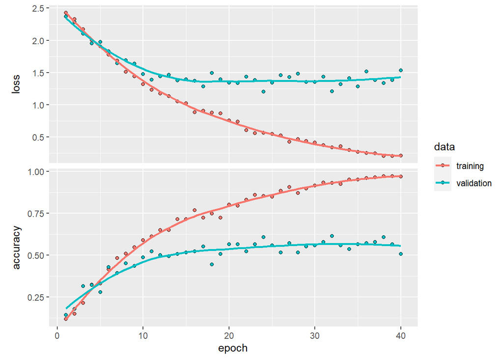

```r
# Cnn Parametri migliori ---------------------------

dropout = 0.4

filter1 = 32
filter2 = 64
filter3 = 128

kernel1 = 4
kernel2 =3
kernel3 =2

neuroni=512

l2 = 0.0001
lr = 0.0001

#CNN_best ------------------------------------------------

model = keras_model_sequential() %>%
  layer_conv_2d(filters = filter1,
                kernel_size = c(kernel1,kernel1),
                activation = "relu",input_shape = c(288,432,3))%>%
  layer_max_pooling_2d(c(2,2))%>%
  layer_conv_2d(filters = filter2,
                kernel_size = c(kernel2,kernel2),
                activation = "relu")%>%
  layer_max_pooling_2d(c(2,2))%>%
  layer_conv_2d(filters = filter3,
                kernel_size = c(kernel3,kernel3),
                activation = "relu")%>%
  layer_max_pooling_2d(c(2,2))%>%
  layer_conv_2d(filters = filter3,
                kernel_size = c(kernel3,kernel3),
                activation = "relu")%>%
  layer_max_pooling_2d(c(2,2))%>%
  layer_flatten()%>%
  layer_dropout(dropout) %>%
  layer_dense(units = neuroni,
              activation = 'relu',kernel_regularizer = regularizer_l2(l = l2)) %>%
  layer_dense(units = 10,activation = "softmax")


model %>% compile(
  loss = "categorical_crossentropy",
  optimizer = optimizer_adam(learning_rate = lr),
  metrics = "accuracy")

summary(model)


early_stop = callback_early_stopping(
  monitor='val_loss', min_delta=0, patience=10)

epochs = 40
step_per_epoca = 17
validation_step = 7
batch_size = 8

history <- model %>% fit(
  train_generator,
  epochs = epochs,
  validation_data=validation_generator,
  batch_size=8,
  steps_per_epoch = step_per_epoca,
  validation_steps=validation_step
)

plot(history)
```

Si individuano ora i risultati sul test set

```r
score <- model %>% evaluate(
  test_generator)
```

```r
cat('Test loss:', score[1], '\n')
```

```
Test loss: 1.487405
```

```r
cat('Test accuracy:', score[2], '\n')
```

```
Test accuracy: 0.58
```

E si mostra la confusion matrix.

```r
prev=model %>%
  predict(test_generator)%>%
  k_argmax()

prev=as.factor(as.numeric(prev)+1);levels(prev)=levels(feature_extrac$genre)

y=as.factor(test_generator$labels+1);levels(y)=levels(feature_extrac$genre)
confusionMatrix(prev,y)
```

```
Confusion Matrix and Statistics

           Reference
Prediction  blues classical country disco hiphop jazz metal pop reggae rock
  blues         2         0       0     0      0    0     0   0      0    0
  classical     0         9       0     0      0    3     0   0      0    0
  country       1         1       3     2      0    0     0   0      0    3
  disco         1         0       4     6      0    0     2   0      0    0
  hiphop        0         0       0     1      5    0     0   0      1    0
  jazz          0         0       1     0      0    7     0   0      0    0
  metal         0         0       0     0      0    0     7   0      0    2
  pop           0         0       1     0      1    0     0   8      0    0
  reggae        4         0       1     1      4    0     0   2      8    2
  rock          2         0       0     0      0    0     1   0      1    3

Overall Statistics

               Accuracy : 0.58
                 95% CI : (0.4771, 0.678)
    No Information Rate : 0.1
    P-Value [Acc > NIR] : < 2.2e-16

                  Kappa : 0.5333

 Mcnemar's Test P-Value : NA

Statistics by Class:

                     Class: blues Class: classical Class: country Class: disco
Sensitivity                0.2000           0.9000         0.3000       0.6000
Specificity                1.0000           0.9667         0.9222       0.9222
Pos Pred Value             1.0000           0.7500         0.3000       0.4615
Neg Pred Value             0.9184           0.9886         0.9222       0.9540
Prevalence                 0.1000           0.1000         0.1000       0.1000
Detection Rate             0.0200           0.0900         0.0300       0.0600
Detection Prevalence       0.0200           0.1200         0.1000       0.1300
Balanced Accuracy          0.6000           0.9333         0.6111       0.7611
                     Class: hiphop Class: jazz Class: metal Class: pop
Sensitivity                 0.5000      0.7000       0.7000     0.8000
Specificity                 0.9778      0.9889       0.9778     0.9778
Pos Pred Value              0.7143      0.8750       0.7778     0.8000
Neg Pred Value              0.9462      0.9674       0.9670     0.9778
Prevalence                  0.1000      0.1000       0.1000     0.1000
Detection Rate              0.0500      0.0700       0.0700     0.0800
Detection Prevalence        0.0700      0.0800       0.0900     0.1000
Balanced Accuracy           0.7389      0.8444       0.8389     0.8889
                     Class: reggae Class: rock
Sensitivity                 0.8000      0.3000
Specificity                 0.8444      0.9556
Pos Pred Value              0.3636      0.4286
Neg Pred Value              0.9744      0.9247
Prevalence                  0.1000      0.1000
Detection Rate              0.0800      0.0300
Detection Prevalence        0.2200      0.0700
Balanced Accuracy           0.8222      0.6278
```

# PARTE 2

## Estrazione Features

Si imposta ora la directory per importare i file audio. Vengono poi letti tramite il comando list.files di cui si mostra un piccolo output. Si noti come i file totali alla fine sono esattamente pari a 1000 come quelli presenti nel dataset.

```r
setwd("C:/Users/matte/Desktop/audio")
fnam=file.path("tutti")
filist=list.files(fnam, recursive=TRUE, pattern="wav")
head(filist)
```

```
[1] "blues.00000.wav" "blues.00001.wav" "blues.00002.wav" "blues.00003.wav"
[5] "blues.00004.wav" "blues.00005.wav"
```

```r
filist1=paste(fnam, "/", filist, sep="")
nfiles=length(filist1)
nfiles
```

```
[1] 1000
```

Si procede ora a mostrare l’immagine della prima “traccia” presente nel dataset che servirà per estrarre le features di interesse. Al centro dell’analisi acustica con il pacchetto soundgen c’è la trasformata di Fourier di breve durata (STFT): si osserva un breve segmento di suono alla volta (un frame STFT), si analizza il suo spettro utilizzando la trasformata di Fourier veloce (FFT), e quindi ci sposta alla cornice successiva, sovrapponendo le due trovate. Per analizzare un suono con le impostazioni predefinite e tracciarne lo spettrogramma, tutto ciò che dobbiamo specificare è la sua frequenza di campionamento (l’impostazione predefinita in soundgen è 16000 Hz):

```r
setwd("C:/Users/matte/Desktop/audio")
fnam=file.path("tutti")
filist=list.files(fnam, recursive=TRUE, pattern="wav")
head(filist)
```

```
[1] "blues.00000.wav" "blues.00001.wav" "blues.00002.wav" "blues.00003.wav"
[5] "blues.00004.wav" "blues.00005.wav"
```

```r
filist1=paste(fnam, "/", filist, sep="")
nfiles=length(filist1)
nfiles
```

```
[1] 1000
```

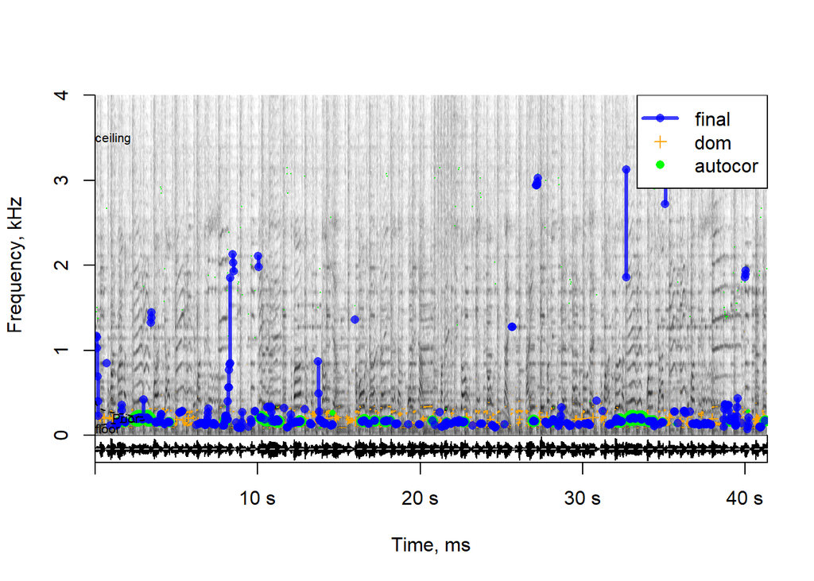

```r
inname=filist1[1]
ywave=readWave(inname)
L=ywave@left
a1 = analyze(L, samplingRate = 16000, plot = TRUE, ylim = c(0, 4))
```

Tramite l’immagine creata si possono ricavare ben 164 features differenti riguardanti moltissime informazioni sul suono. Si utilizza quindi questa metodologia per estrarre da ogni traccia le features fondamentali. Si noti che il ciclo va incontro ad un errore al passo 555. La traccia in questione infatti presenta dei difetti e non viene caricata correttamente. Il ciclo quindi è stato poi fatto ripartire in seguito. Per non perdere di formalità si preferisce mostrare il tutto senza le modifiche effettuate.

```r
feat_extract=matrix(0,nrow=1000,ncol=164)
colnames(feat_extract)=colnames(a1$summary)


#ciclo
tic()
x = rep(x = NA, times = 444)
pb = txtProgressBar(0, length(x), style = 3)
for (i in 1:nfiles){
  setTxtProgressBar(pb, i)
  x[i]
  inname=filist1[i]
  ywave=readWave(inname)
  L=ywave@left
  a1 = analyze(L, samplingRate = 16000, plot = FALSE)
  feat_extract[i,]=c(unlist(as.vector(a1$summary)))
  uno=sub(".*tutti/", "", filist1[i])
  due=sub("\\..*", "", uno)
  feat_extract[i,1]=c(due)
}
toc()
#parte uno 34961.62 sec elapsed + 96801.83
```

Si noti come il tempo totale sia di circa 36 ore. Una volta eseguito il ciclo si è scoperto che nella traccia numero 181 erano presenti dei NA. Si è cosi deciso di togliere questo file per non aver problemi in fase di applicazione dei modelli.

```r
df=feat_extract;df=as.data.frame(df);which(df$file==0);df=df[-555,];sum(is.na(df))

apply(is.na(df), 2, which);df=df[-181,];sum(is.na(df))


df1 = lapply(a[,-1],as.numeric)
df1 = as.data.frame(df1)
df1=cbind(df1,genre=a$file)

#write.csv2(x = df1,file = "feature_extrac.csv")
```

Una volta salvato il file è cosi possibile caricarlo senza rieseguire da zero i passaggi precedenti risparmiando cosi del tempo computazionale.

## Applicazione Feed Forward Neural Network

```r
feature_extrac = read.csv2("C:/Users/matte/Desktop/feature_extrac.csv")
feature_extrac$genre=as.factor(feature_extrac$genre)
```

Guardiamo ora quali sono le quantità estratte in precedenza dai file audio

```r
colnames(feature_extrac)
```

```
  [1] "X"                         "duration"
  [3] "duration_noSilence"        "voiced"
  [5] "voiced_noSilence"          "amEnvDep_mean"
  [7] "amEnvDep_median"           "amEnvDep_sd"
  [9] "amEnvDepVoiced_mean"       "amEnvDepVoiced_median"
 [11] "amEnvDepVoiced_sd"         "amEnvFreq_mean"
 [13] "amEnvFreq_median"          "amEnvFreq_sd"
 [15] "amEnvFreqVoiced_mean"      "amEnvFreqVoiced_median"
 [17] "amEnvFreqVoiced_sd"        "amEnvPurity_mean"
 [19] "amEnvPurity_median"        "amEnvPurity_sd"
 [21] "amEnvPurityVoiced_mean"    "amEnvPurityVoiced_median"
 [23] "amEnvPurityVoiced_sd"      "amMsFreq_mean"
 [25] "amMsFreq_median"           "amMsFreq_sd"
 [27] "amMsFreqVoiced_mean"       "amMsFreqVoiced_median"
 [29] "amMsFreqVoiced_sd"         "amMsPurity_mean"
```

[output cut: 68 more lines]

A questo punto bisogna trasformare i nostri dati in matrici leggibili da keras. Questo viene fatto nel seguente modo:

```r
data = as.matrix(feature_extrac)
dimnames(data) = NULL
ncol(data)
```

```
[1] 165
```

```r
data[, 165] = as.numeric(as.factor(data[, 165])) - 1 #conversione factor in numerico
mode(data) = "numeric"
```

Il comando mode(data) rende automaticamente tutto ciò presente nella matrice create come una quantità numerica

Si sono cosi suddivisi i dati training, validation e test….applicando una normalizzazione richiesta dalla rete neurale per poter rendere confrontabili le features.

```r
set.seed(321)
indx = sample(3,
               nrow(data),
               replace = TRUE,
               prob = c(0.6, 0.3, 0.1))


x_train = data[indx == 1, 1:164] # Take rows with index = 1
x_vali = data[indx == 2, 1:164]
x_test = data[indx == 3, 1:164]

y_test_actual = data[indx == 3, 165]

y_train =to_categorical(data[indx == 1, 165])
y_vali = to_categorical(data[indx == 2, 165])
y_test = to_categorical(data[indx == 3, 165])

mean_train = apply(x_train, 2, mean)
std_train = apply(x_train, 2, sd)
x_train = scale(x_train, center = mean_train, scale = std_train)
x_vali = scale(x_vali, center = mean_train, scale = std_train)
x_test = scale(x_test, center = mean_train, scale = std_train)
```

Si è costruita cosi la rete neurale che dopo molti tentativi di tuning è risultata la seguente:

```r
model = keras_model_sequential()

model %>%
  layer_dense(units = 512, activation = "relu", input_shape = c(164)) %>%
  layer_dropout(rate = 0.3) %>%
  layer_dense(units = 256, activation = "relu") %>%
  layer_dropout(rate = 0.3) %>%
  layer_dense(units = 128, activation = "relu") %>%
  layer_dropout(rate = 0.3) %>%
  layer_dense(units = 64, activation = "relu") %>%
  layer_dropout(rate = 0.3) %>%
  layer_dense(units = 10, activation = "softmax")
summary(model)
```

```
Model: "sequential_2"
________________________________________________________________________________
Layer (type)                        Output Shape                    Param #
================================================================================
dense_8 (Dense)                     (None, 512)                     84480
________________________________________________________________________________
dropout_5 (Dropout)                 (None, 512)                     0
________________________________________________________________________________
dense_7 (Dense)                     (None, 256)                     131328
________________________________________________________________________________
dropout_4 (Dropout)                 (None, 256)                     0
________________________________________________________________________________
dense_6 (Dense)                     (None, 128)                     32896
________________________________________________________________________________
dropout_3 (Dropout)                 (None, 128)                     0
________________________________________________________________________________
dense_5 (Dense)                     (None, 64)                      8256
________________________________________________________________________________
dropout_2 (Dropout)                 (None, 64)                      0
________________________________________________________________________________
dense_4 (Dense)                     (None, 10)                      650
================================================================================
Total params: 257,610
Trainable params: 257,610
Non-trainable params: 0
________________________________________________________________________________
```

Eseguendo la rete il risultato che si ottiene è il seguente:

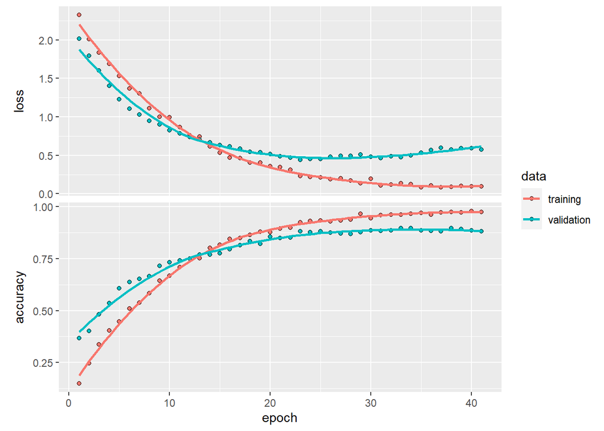

```r
#COSTRUZIONE RETEEEE-------------------



model %>% compile(loss = "categorical_crossentropy",
                  optimizer = "adam",
                  metrics = c("accuracy"))


#---------FIT RETEEEEEEEEEE
history = model %>% fit(x_train, y_train,
                        batch_size = 128,
                        epochs = 41,
                        validation_data=list(x_vali,y_vali))

plot(history)
```

Fittando la rete sul test seti si ottiene il seguente risultato:

```r
pred = model %>%
  predict_classes(x_test)

prev=as.factor(pred);levels(prev)=levels(feature_extrac$genre)
y=as.factor(y_test_actual);levels(y)=levels(feature_extrac$genre)

confusionMatrix(prev,y)
```

```
Confusion Matrix and Statistics

           Reference
Prediction  blues classical country disco hiphop jazz metal pop reggae rock
  blues        13         2       1     0      0    0     0   0      0    0
  classical     0         7       0     0      0    0     0   0      0    0
  country       0         0      12     0      0    0     0   0      0    0
  disco         0         0       1     5      0    0     1   1      0    0
  hiphop        0         0       0     2     13    0     0   0      1    0
  jazz          0         0       0     0      0    9     0   0      0    1
  metal         0         0       0     0      0    0    10   0      0    1
  pop           0         0       0     0      1    0     0  10      1    0
  reggae        0         0       0     0      0    0     0   0     14    1
  rock          0         0       0     0      0    0     0   0      0    5

Overall Statistics

               Accuracy : 0.875
                 95% CI : (0.7992, 0.9299)
    No Information Rate : 0.1429
    P-Value [Acc > NIR] : < 2.2e-16

                  Kappa : 0.86

 Mcnemar's Test P-Value : NA

Statistics by Class:

                     Class: blues Class: classical Class: country Class: disco
Sensitivity                1.0000          0.77778         0.8571      0.71429
Specificity                0.9697          1.00000         1.0000      0.97143
Pos Pred Value             0.8125          1.00000         1.0000      0.62500
Neg Pred Value             1.0000          0.98095         0.9800      0.98077
Prevalence                 0.1161          0.08036         0.1250      0.06250
Detection Rate             0.1161          0.06250         0.1071      0.04464
Detection Prevalence       0.1429          0.06250         0.1071      0.07143
Balanced Accuracy          0.9848          0.88889         0.9286      0.84286
                     Class: hiphop Class: jazz Class: metal Class: pop
Sensitivity                 0.9286     1.00000      0.90909    0.90909
Specificity                 0.9694     0.99029      0.99010    0.98020
Pos Pred Value              0.8125     0.90000      0.90909    0.83333
Neg Pred Value              0.9896     1.00000      0.99010    0.99000
Prevalence                  0.1250     0.08036      0.09821    0.09821
Detection Rate              0.1161     0.08036      0.08929    0.08929
Detection Prevalence        0.1429     0.08929      0.09821    0.10714
Balanced Accuracy           0.9490     0.99515      0.94959    0.94464
                     Class: reggae Class: rock
Sensitivity                 0.8750     0.62500
Specificity                 0.9896     1.00000
Pos Pred Value              0.9333     1.00000
Neg Pred Value              0.9794     0.97196
Prevalence                  0.1429     0.07143
Detection Rate              0.1250     0.04464
Detection Prevalence        0.1339     0.04464
Balanced Accuracy           0.9323     0.81250
```